# Falando sobre Controle Estatístico de Processo

Por Thiago Ledur Hoeflich

Todo individuo faz diversas tarefas durante o seu dia, muitas delas consideramos automáticas, fazemos sem perceber, pois é repetida de forma periódica. Atrás desse processo de repetição acabamos achando a melhor forma de executar as tarefas em nossos mundos limitados, ignorando informações que podem deixar tudo mais fácil.

O que fazemos nada mais é do que criarmos processos, que internalizamos, considerando-os ideais, pois temos dificuldades, como seres humanos, de aceitar mudanças propostas por outros indivíduos, buscando uma melhora do processo como um todo, necessário uma quebra de paradigmas.

[figure not shown]

# Onde se encaixa a estatística?

Com um Controle Estatístico de Processos é possível alcançar padrões mais elevados, com eficiência e eficácia, atingir maior retorno em diversas áreas e processos, para isso é necessário definir o processo, as características a serem controladas, análise de performance, planejamento, implementação, avaliação e monitoramento, aliado a filosofia de melhoria continua, conciliando teorias administrativas e estatísticas a fim do mesmo objetivo, a melhora do processo.

As principais aplicações do Controle Estatístico de Processono pelo estatístico se da através de: **Gráficos de Controle**, necessário para o monitoramento da produção ao longo do tempo; **Análise da Capacidade de Processo**, identificando se a produção atende as especificações; **Análise da Confiabilidade de Medidores**, examinar a exatidão dos instrumentos que mensuram as características da qualidade; e **Técnicas de Amostragem de Aceitação**, sendo a tomada de decisão com base nas amostras.

[figure not shown]

O Gráficos de Controle serve para mostrar a variação do indicador ao longo do tempo, com limites arbitrários, para identificar a variabilidade natural do processo. Modelos não normalizados não permitem respostas claras para os demais passos do Controle Estatístico de Processos.

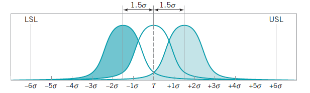

A Análise de Capacidade de Processo o estatístico é a verificação da variabilidade do processo em relação as especificações previamente determinado do produto, instantânea ou ao longo do tempo, através de índices e ferramentas estatísticas para mensurar a variação, amplitude e performance. Porem o processo deve estar normalizado para se identificar variações que possam ter uma explicação no mundo real, ajustando o processo a fim de alcançar parâmetros Six Sigma, que por sua vez utiliza outras ferramentas como DMAIC que é um acrônimo para: Definir, Medir, Analisar, Melhorar e Controlar.

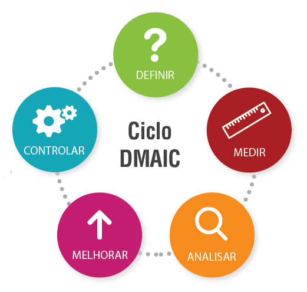

Análise da Confiabilidade de Medidores é a etapa destinada a verificar se os medidores estão medindo corretamente (calibrado) e são eficientes para os objetivos do projeto/produto.

Técnicas de Amostragem de Aceitação serve para identificar a qualidade dos insumos dos fornecedores, aceitando ou rejeitando lotes, utilizando tecnicas diferentes para avaliar diferentes insumos, como modelagem única, dupla, múltipla, sequencial, entre outras.

# Como está o cenário atual?

No cenário nacional percebe-se um controle estatístico somente em empresas multinacionais ou que fazem parte da cadeia de fornecimento para estas grandes corporações. Empresas de menor porte não perceberam a importância ou não possuem estrutura mínima para incorporar processos que impactam em todos os setores. O entendimento de muitos gestores é somente o corte de custos e despesas imediatas, levando a empresa ao declínio, culpando a conjuntura econômica do pais, não visualizando o cenário interno da empresa.

# Estatístico no Controle de Processo

Com isso percebemos que dentro de um simples assunto, existe uma vasta área em que o estatístico pode atuar e explorar, buscando novas metodologias, ferramentas e índices que auxiliam na tomada de decisão, pois todas as empresas buscan o controle sobre seus insumos, em que o Estatístico é um dos profissionais que geram relatórios que informam a situação da produção para a tomada de decisão pelo Administrador.

# Referências

MONTGOMERY, Douglas C. . **Introduction to Statistical Quality Control**. 7. ed. Wiley, 2009.